# AIPC 2023-2024

## Introduction à Python™

## Pourquoi devrais-je apprendre Python ?

- Parce que c'est *cool* et parce que le logo est *fun*
- Parce que c'est gratuit et disponible sur toutes les plateformes
- Parce que c'est un langage de haut niveau, qui est facile à lire en Anglais, et qui ne possède pas une syntaxe bizarre

```python
import random
def choose_color():
    colors=['red','green','blue']
    return random.choice(colors)

my_color=choose_color()
print(my_color)
```

```
green
```

- Parce que c'est un langage interprété qui peut être lancé en mode interactif
- Parce qu'il est possible de faire de la science avec (il existe de nombreuses librairies)
- Parce que c'est devenu un standard

## Pourquoi devrais-je apprendre Python ? (suite)

- Parce que *je* dois !

Extraits de programmes

- Seconde, sciences numériques

[figure not shown]

- Seconde, physique chimie

[figure not shown]

- Première, enseignement scientifique

[figure not shown]

- Programme de prépa, MPSI

[figure not shown]

- Voir aussi dans les [rapports de jury de l'agrégation interne de Physique/Chimie](http://www.agregation-interne-physique-chimie.org/rapports-de-jury.html).

## Où et comment utiliser Python ? 1/2

### Au travers une interface *notebook* sur le *cloud*

Pour :

- rien à installer, pas de soucis de mises à jour
- facile à utiliser
- tout est sur le *cloud*
- outil sur la base d'un navigateur, donc fonctionnant sur toute plateforme

Contre :

- indisponible hors ligne
- difficile d'interagir avec du matériel local

Où ?

- Ici à l'université https://jupy.physique.univ-paris-diderot.fr
- Ailleurs comme https://colab.research.google.com ou https://mybinder.org/
- Ou sur toute installation disponible comme https://capytale2.ac-paris.fr par exemple

## Où et comment utiliser Python ? 2/2

### Sur une machine locale

Poour :

- toujours disponible quelque soit l'état du réseau
- possible de gérer la version
- interaction facilité avec du matériel

Contre :

- nécessite l'effectuer les installations et les mises à jour
- non disponible sur le nuage (attention aux sauvegardes)

Quelle version :

- Python 3 (python 2 n'est plus maintenu depuis un peu plus de 1 an)
- Il est envisageable d'installer python via `spyder` ou `anaconda` (qui vient directement avec `spyder`, `iPython`, `SciPy`…)

## Très courte introduction de l'utilisation du mode interactif

Référence : https://docs.python.org/3/

### Faire un simple calcul

```python
1+2+3
```

```
6
```

Mais…

```python
sin(pi/2)
```

```
---------------------------------------------------------------------------
NameError                                 Traceback (most recent call last)
Cell In[3], line 1
----> 1 sin(pi/2)

NameError: name 'sin' is not defined
```

Vous devez alors utiliser le module `math` :

```python
import math
math.sin(math.pi/2)
```

```
1.0
```

Si vous ne souhaitez pas écrire à chaque fois `math.` au début des commandes :

```python
import math as m
m.sin(m.pi/2)
```

```
1.0
```

ou alors (même si c'est une méthode dangereuse car certains modules ont des noms de variables ou fonctions identiques)

```python
# would be better to avoid this method
# please note that you can add a comment adding a dash at the beg of a line
from math import *
sin(pi/2)
```

```
1.0
```

### Quelques types disponibles

On peut soit laisser Python choisir le type par défaut ou alors forcer celui-ci.

```python
a=2
print(a)
print(type(a))

b=12.34
print(b)
print(type(b))

c=float(3)
print(c)
print(type(c))

x=[0,1,2]
print(x)
print(type(x))

s="hi everybody !"
print(s)
print(type(s))
```

```
2
<class 'int'>
12.34
<class 'float'>
3.0
<class 'float'>
[0, 1, 2]
<class 'list'>
hi everybody !
<class 'str'>
```

### Opérateurs

```python
# addition with + for integers
a=1
b=2
print(a+b)

#concatenation with + for strings
s1="hello "
s2="world"
print(s1+s2)
```

```
3
hello world
```

Référence sur les opérateurs : voir https://docs.python.org/3/library/operator.html

### Listes, boucles simples et structures de contrôle

```python
a=[1,2,3,4]
b=[5,6,7,8]
print(a+b)
```

```
[1, 2, 3, 4, 5, 6, 7, 8]
```

```python
for x in a:
    print(x+2) # yes there is an indent here. Required for block of commands
```

```
3
4
5
6
```

Il est possible de créer des listes inhomogènes aussi

```python
z=[0,True,3.4,"pi",[5,6]]
print(z)
print(type(z))
```

```
[0, True, 3.4, 'pi', [5, 6]]
<class 'list'>
```

Afin d'accéder à un élément en particulier, il faut spécifier l'index, qui commence à 0.

```python
print(z[0])
print(z[3])
print(z[-1]) # means last element
```

```
0
pi
[5, 6]
```

Mais il n'est pas possible de vraiment faire du calcul scientifique avec des listes simples…

```python
x=[1,2,3]
print(2*x+3)
```

```
---------------------------------------------------------------------------
TypeError                                 Traceback (most recent call last)
Cell In[13], line 2
      1 x=[1,2,3]
----> 2 print(2*x+3)

TypeError: can only concatenate list (not "int") to list
```

Pour en savoir plus sur le langage, en particulier sur les structures de contrôle (utilisation de `for`, `if`, `while`, ...), se référer à la documentation.

https://docs.python.org/3/tutorial/controlflow.html?highlight=loop#

Exemple avec l'algorithme d'Eratosthene.

```python
def eratosthene(n):
    n += 1
    p = [0,0] + [i for i in range(2, n)]
    for i in range(2, n):
        if p[i] != 0:
            for j in range(i*2, n, i):
                p[j] = 0
    return [v for v in p if v!=0]

eratosthene(50)
```

```
[2, 3, 5, 7, 11, 13, 17, 19, 23, 29, 31, 37, 41, 43, 47]
```

## Paquest scientiques

Numpy Scipy Matplotlib

Références : https://www.scipy.org/

Voyons quelques exemples pratiques.

### Calcul avec des (numpy) arrays

On se rappelle…

```python
a=[1,2,3,4]
b=[5,6,7,8]
print(a+b)
```

```
[1, 2, 3, 4, 5, 6, 7, 8]
```

Mais…

```python
import numpy as np
x=np.array(a)
y=np.array(b)
z=np.add(x,y)
print(type(z))
print(z)
```

```
<class 'numpy.ndarray'>
[ 6  8 10 12]
```

Créer et utiliser un *range array* :

```python
theta=np.arange(-m.pi,m.pi,0.1)
y=np.cos(theta)
print(y)
```

```
[-1.         -0.99500417 -0.98006658 -0.95533649 -0.92106099 -0.87758256
 -0.82533561 -0.76484219 -0.69670671 -0.62160997 -0.54030231 -0.45359612
 -0.36235775 -0.26749883 -0.16996714 -0.0707372   0.02919952  0.12884449
  0.22720209  0.32328957  0.41614684  0.5048461   0.58850112  0.66627602
  0.73739372  0.80114362  0.85688875  0.90407214  0.94222234  0.97095817
  0.9899925   0.99913515  0.99829478  0.98747977  0.96679819  0.93645669
  0.89675842  0.84810003  0.79096771  0.7259323   0.65364362  0.57482395
  0.49026082  0.40079917  0.30733287  0.2107958   0.11215253  0.01238866
 -0.08749898 -0.18651237 -0.28366219 -0.37797774 -0.46851667 -0.55437434
 -0.63469288 -0.70866977 -0.77556588 -0.83471278 -0.88551952 -0.92747843
 -0.96017029 -0.98326844 -0.9965421 ]
```

Créer un tableau entre 2 flottants avec N valeurs

```python
z=np.linspace(-2,10,25)
print(z)
```

```
[-2.  -1.5 -1.  -0.5  0.   0.5  1.   1.5  2.   2.5  3.   3.5  4.   4.5
  5.   5.5  6.   6.5  7.   7.5  8.   8.5  9.   9.5 10. ]
```

Créer un tableau de nombres aléatoires :

```python
flat_noise=np.random.random(50)
print(flat_noise)
```

```
[0.38360898 0.46197246 0.69547495 0.22666558 0.66809159 0.03415835
 0.3268381  0.17221703 0.52095282 0.49597678 0.08281867 0.29144201
 0.03603037 0.24758746 0.74682722 0.14047721 0.63832806 0.25957692
 0.43084486 0.09686145 0.83026568 0.86960088 0.52541158 0.53805603
 0.95618234 0.50623158 0.99026603 0.48627549 0.38999131 0.54403036
 0.77921347 0.59192899 0.87174277 0.43948965 0.98448636 0.75146265
 0.25231084 0.33596766 0.33554805 0.03070714 0.49443179 0.49634966
 0.1556993  0.11562439 0.99720163 0.99413707 0.08989822 0.53646467
 0.00132651 0.34046848]
```

### Tracés avec MatplotLib

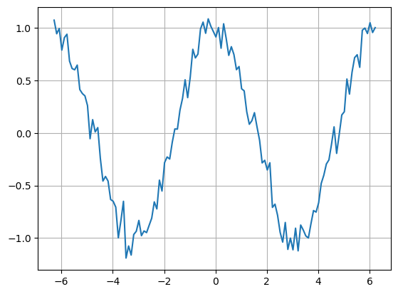

```python
import numpy as np
import matplotlib.pyplot as plt
import math as m
x=np.arange(-2*m.pi,2*m.pi,0.1)
y=np.cos(x)
y_noise=0.1*np.random.randn(y.size) # normal distribution of noise
plt.plot(x,y+y_noise)
plt.grid()
```

Afin d'interagir avec le graphique (zoom, déplacement, sauvegarde de la figure), il faut lancer une commande MatplotLib spécifique (attention, ne fonctionne pas dans tous les environnements…).

```python
%matplotlib widget
```

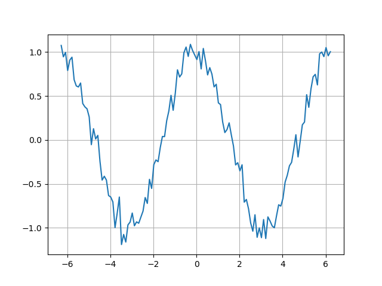

```python
# You have to try this in the notebook directly...
plt.plot(x,y+y_noise)
plt.grid()
```

### Ajustements

#### Ajustement linéaire avec SciPy

Mais il n'est pas aisé de récupérer les erreurs sur les paramètres ajustés…

```
(-2.6365281575231, 3.327922749449664)
```

[figure not shown]

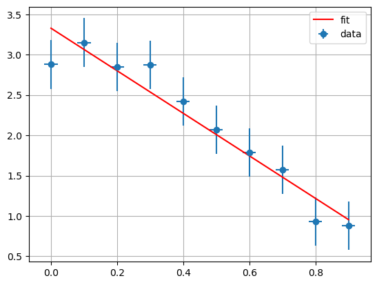

```python
plt.figure()

from scipy import stats
x=np.arange(0,1,0.1)
dx=0.02
dy=0.3
y=-2*x+3+np.random.normal(0,dy,x.size)
r = stats.linregress(x,y)
mn=np.min(x)
mx=np.max(x)
x1=np.linspace(mn,mx,500)
y1=r.slope*x1+r.intercept
plt.errorbar(x,y,xerr=dx,yerr=dy,fmt='o',label='data')
plt.plot(x1,y1,'-r',label='fit')
plt.legend()
plt.grid()
print((r.slope,r.intercept))
```

#### Ajustement linéaire avec fitutils

Attention : `fitutils` n'est pas un outil standard mais il est disponible sur votre server préféré ;) . Si vous cherchez ce module, vous le trouverez sur le server `jupy` dans `/home/libs/` (sauf s'il y a eu des modifications de configuration dernièrement…)

Ce moudle est une nouvelle branche (version) de l'outil MatlabⓇ `linfitxy` disponible à https://github.com/tjbtjbtjb/linfitxy.

Principal avantage de cet outil : il gère les erreurs à la fois en `Y` et en `X`, alors que la plupart des outils ne le font pas.

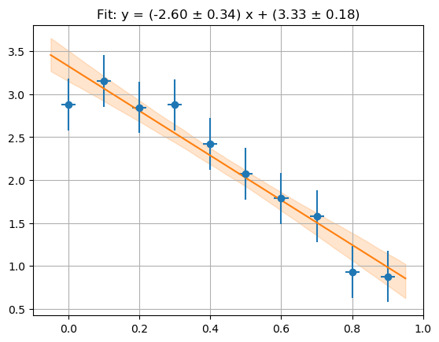

```python
import fitutils as fu
dx=np.ones(x.size)*dx
dy=np.ones(y.size)*dy
fu.linfitxy(x,y,dx,dy,plot=True)
plt.grid()
```

#### Ajustement non linéaire

Il peut être réaliser soit avec `polyfit` (pour les polynômes) ou avec `curvefit` (pour n'importe quelle fonction). On pourra préférer ce `curvefit` car on peut facilement récupérer les erreurs des paramètres ajustés. Voir ci-dessous.

```python
def f1(x,a,b,c):
    return a*x**2+b*x+c

N=15
x_exp=np.random.random(N)*10-5   # Get random x between -5 and +5
y=f1(x_exp,-2,3,60)         # Compute y
dy=np.random.randn(N)*5         # Some noise
y_exp=y+dy                       # Let's assume those are experimental data

# Fitting with polyfit
p=np.polyfit(x_exp,y_exp,2)   # Fit with numpy.polyfit
print(p)

# Fitting with curvefit, try to fit a normal
from scipy import optimize
from scipy.stats import norm
def f2(x,m,s,n):
    return n*norm.pdf(x,m,s)

param,cov=optimize.curve_fit(f2,x_exp,y_exp,p0=[0,1,10],sigma=np.ones(N)*5)
err=np.zeros(np.size(param))
for i in range(np.size(param)):
    err[i]=m.sqrt(cov[i][i])
print(param,err)
```

```
[-2.22121171  4.2678675  59.68982359]
[  1.0827278    3.0879302  488.48591344] [ 0.11848081  0.13977734 18.71267815]
```

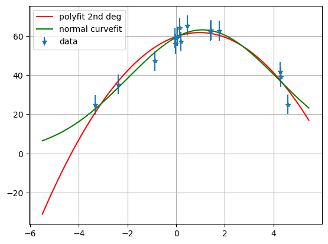

```python
plt.errorbar(x_exp,y_exp,yerr=5,fmt='*',label='data')
x=np.arange(-5.5,5.5,0.05)
plt.plot(x,f1(x,p[0],p[1],p[2]),'r',label='polyfit 2nd deg')
plt.plot(x,f2(x,param[0],param[1],param[2]),'g',label='normal curvefit')
plt.grid()
plt.legend()
```

### Quelques éléments de statistique

```
1.010514592635117 -3.1658190149717345 -3.1073220080966326
```

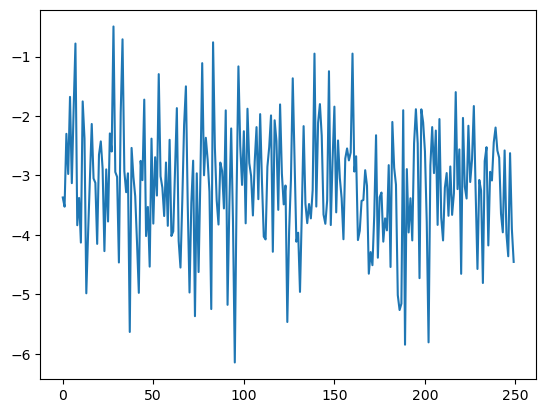

```python
import numpy as np
x=np.random.normal(-3,1,250)
plt.plot(x)
s=np.std(x)
m=np.mean(x)
m2=np.median(x)
print(s,m,m2)
```

### Histogrammes

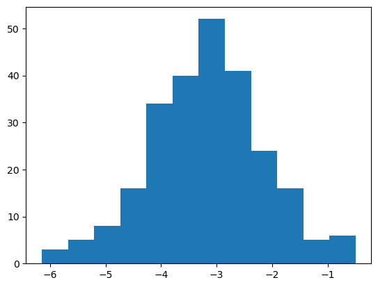

```python
histo,edges,z=plt.hist(x,12)
```

## D'autres petites choses variés en python…

### Lire un simple texte

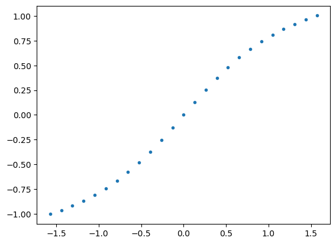

```python
import matplotlib.pyplot as plt
with open('file1.txt', 'r') as f:
    lines = f.readlines()
    x = [float(line.split()[0]) for line in lines]
    y = [float(line.split()[1]) for line in lines]
plt.plot(x ,y,'.')
plt.show()
```

## Lire un fichier issu d'un tableau (`csv`, `xlsx`, `json`, voire issu d'un tableau web)

On utilisera pour cela utilement l'outil `pandas`, mais dont la puissance n'a d'égal que sa potentielle complexité. À essayer ! Deux exemples ci-dessous.

https://pandas.pydata.org/

```python
import pandas as pd
```

```python
# cf. https://www.data.gouv.fr/fr/datasets/donnees-relatives-aux-personnes-vaccinees-contre-la-covid-19-1/
vacc=pd.read_csv('https://www.data.gouv.fr/fr/datasets/r/e6fcd558-2ff6-487b-b624-e64a8c05bb07',sep=';')
display(vacc)
```

|  | fra | clage_vacsi | jour | n_dose1_h | n_complet_h | n_rappel_h | n_2_rappel_h | n_rappel_biv_h | n_3_rappel_h | n_cum_dose1_h | ... | n_cum_rappel_e | n_cum_2_rappel_e | n_cum_rappel_biv_e | n_cum_3_rappel_e | couv_dose1_e | couv_complet_e | couv_rappel_e | couv_2_rappel_e | couv_rappel_biv_e | couv_3_rappel_e |
| --- | --- | --- | --- | --- | --- | --- | --- | --- | --- | --- | --- | --- | --- | --- | --- | --- | --- | --- | --- | --- | --- |
| 0 | FR | 4 | 2020-12-27 | 1 | 0 | 0 | 0 | 0 | 0 | 1 | ... | 0 | 0 | 0 | 0 | 0.0 | 0.0 | 0.0 | 0.0 | 0.0 | 0.0 |
| 1 | FR | 4 | 2020-12-28 | 1 | 0 | 0 | 0 | 0 | 0 | 2 | ... | 0 | 0 | 0 | 0 | 0.0 | 0.0 | 0.0 | 0.0 | 0.0 | 0.0 |
| 2 | FR | 4 | 2020-12-29 | 1 | 0 | 0 | 0 | 0 | 0 | 3 | ... | 0 | 0 | 0 | 0 | 0.0 | 0.0 | 0.0 | 0.0 | 0.0 | 0.0 |
| 3 | FR | 4 | 2020-12-30 | 0 | 0 | 0 | 0 | 0 | 0 | 3 | ... | 0 | 0 | 0 | 0 | 0.0 | 0.0 | 0.0 | 0.0 | 0.0 | 0.0 |
| 4 | FR | 4 | 2020-12-31 | 1 | 0 | 0 | 0 | 0 | 0 | 4 | ... | 0 | 0 | 0 | 0 | 0.0 | 0.0 | 0.0 | 0.0 | 0.0 | 0.0 |
| ... | ... | ... | ... | ... | ... | ... | ... | ... | ... | ... | ... | ... | ... | ... | ... | ... | ... | ... | ... | ... | ... |
| 13885 | FR | 0 | 2023-07-06 | 21 | 13 | 54 | 185 | 1188 | 404 | 26423593 | ... | 41041964 | 10229656 | 6240642 | 2344631 | 80.6 | 79.2 | 60.5 | 15.1 | 9.2 | 3.5 |
| 13886 | FR | 0 | 2023-07-07 | 28 | 28 | 70 | 157 | 1268 | 415 | 26423621 | ... | 41042097 | 10230045 | 6243483 | 2345629 | 80.6 | 79.2 | 60.5 | 15.1 | 9.2 | 3.5 |
| 13887 | FR | 0 | 2023-07-08 | 6 | 8 | 29 | 35 | 253 | 70 | 26423627 | ... | 41042147 | 10230131 | 6244008 | 2345798 | 80.6 | 79.2 | 60.5 | 15.1 | 9.2 | 3.5 |
| 13888 | FR | 0 | 2023-07-09 | 1 | 2 | 0 | 2 | 20 | 8 | 26423628 | ... | 41042148 | 10230138 | 6244049 | 2345816 | 80.6 | 79.2 | 60.5 | 15.1 | 9.2 | 3.5 |
| 13889 | FR | 0 | 2023-07-10 | 8 | 16 | 41 | 78 | 680 | 213 | 26423636 | ... | 41042237 | 10230314 | 6245480 | 2346287 | 80.6 | 79.2 | 60.5 | 15.1 | 9.2 | 3.5 |

13890 rows × 57 columns

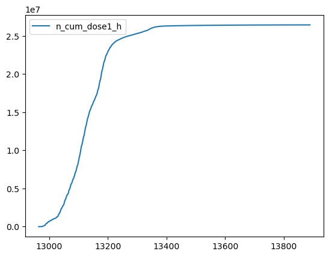

```python
vacc[vacc.clage_vacsi==0][['jour','n_cum_dose1_h']].plot()
```

```python
webpage="https://fr.wikipedia.org/wiki/Population_mondiale"
pop=pd.read_html(webpage)[2]
display(pop)
```

|  | Année | Population mondiale (milliers) | %± | Accroissement brut (millier) |
| --- | --- | --- | --- | --- |
| 0 | 1950 | 2 536 431 | NaN | NaN |
| 1 | 1955 | 2 773 020 | + 9,33 % | 236 589 |
| 2 | 1960 | 3 034 950 | + 9,45 % | 261 930 |
| 3 | 1965 | 3 339 584 | + 10,04 % | 304 634 |
| 4 | 1970 | 3 700 437 | + 10,81 % | 360 854 |
| 5 | 1975 | 4 079 480 | + 10,24 % | 379 043 |
| 6 | 1980 | 4 458 003 | + 9,28 % | 378 523 |
| 7 | 1985 | 4 870 922 | + 9,26 % | 412 918 |
| 8 | 1990 | 5 327 231 | + 9,37 % | 456 309 |
| 9 | 1995 | 5 744 213 | + 7,83 % | 416 982 |
| 10 | 2000 | 6 143 494 | + 6,95 % | 399 281 |
| 11 | 2005 | 6 541 907 | + 6,49 % | 398 413 |
| 12 | 2010 | 6 956 824 | + 6,34 % | 414 917 |
| 13 | 2015 | 7 379 797 | + 6,08 % | 422 973 |
| 14 | 2020 | 7 794 799 | + 5,62 % | 415 002 |
| 15 | Source : ONU, World Population Prospects 2019[... | Source : ONU, World Population Prospects 2019[... | Source : ONU, World Population Prospects 2019[... | Source : ONU, World Population Prospects 2019[... |

### Interaction

*Attention, cela doit être testé au sein d'un notebook et non en mode présentation*

```python
from ipywidgets import interact
import numpy as np
import matplotlib.pyplot as plt
import matplotlib.axes as ax
import math as m

def f(nx,ny,wx,wy,phi):
    t=np.linspace(0,m.pi*4,500)
    x=nx*np.cos(t*wx)
    y=ny*np.cos(t*wy+phi)
    plt.plot(x,y)
    plt.ylim((-2,2))
    plt.xlim((-2,2))
    plt.grid(True)

interact(f,nx=(0,2,0.1),ny=(0,2,0.1),wx=(0,6,0.5),wy=(0,6,0.5),phi=(-m.pi,m.pi,0.1))
```

```
interactive(children=(FloatSlider(value=1.0, description='nx', max=2.0), FloatSlider(value=1.0, description='n…
```

```
<function __main__.f(nx, ny, wx, wy, phi)>
```

## Communication (difficile à tester aujourd'hui, code donné pour référence)

Attention, cela doit être lancé localement, pas dans un notebook

```python
# Assume that arduino has the L/H Builtin LED program uploaded
import serial
s=serial.Serial('/dev/ttyACM0','9600') # One should change the path of the com port according to the actual machine
s.write(b'L')
s.write(b'H')
```

```
---------------------------------------------------------------------------
ModuleNotFoundError                       Traceback (most recent call last)
Cell In[40], line 2
      1 # Assume that arduino has the L/H Builtin LED program uploaded
----> 2 import serial
      3 s=serial.Serial('/dev/ttyACM0','9600') # One should change the path of the com port according to the actual machine
      4 s.write(b'L')

ModuleNotFoundError: No module named 'serial'
```

# Et maintenant ?

Jouons désormais avec Python ! Il faut pour cela se référer à la documentation, aux tutoriels, aux exemples, lire et modifier ceux-ci.

Allons-y !